# Homework 4 – PJM No-Illinois Futures: Seasonality, Monte Carlo, and Operating Value

Group 2: Bailey Meche, Eliott Raia, University of Chicago

April 2026

## Part (a): Log-Linear Regression with Trend and Monthly Seasonality

### Data overview

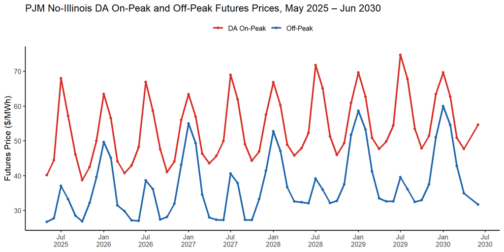

```r
# Quick look at both series
combined_view <- merge(
  pjm_off[,  .(date, Off_Peak = Future)],
  pjm_peak[, .(date, DA_Peak  = Price)],
  by = "date", all = TRUE
)

combined_long <- combined_view %>%
  pivot_longer(cols = c(Off_Peak, DA_Peak),
               names_to = "Contract", values_to = "Price") %>%
  mutate(Contract = factor(Contract,
                           levels = c("DA_Peak","Off_Peak"),
                           labels = c("DA On-Peak","Off-Peak")))

ggplot(combined_long, aes(x = date, y = Price, color = Contract, group = Contract)) +
  geom_line(linewidth = 1.1) +
  geom_point(size = 1.5) +
  scale_x_date(date_breaks = "6 months", date_labels = "%b\n%Y") +
  scale_color_manual(values = c("DA On-Peak" = "#d73027", "Off-Peak" = "#2166ac")) +
  labs(
    title   = "PJM No-Illinois DA On-Peak and Off-Peak Futures Prices, May 2025 – Jun 2030",
    x       = NULL, y = "Futures Price ($/MWh)", color = NULL
  ) +
  theme_classic(base_size = 12) +
  theme(legend.position = "top")
```

### Model specification

We model the natural logarithm of the monthly off-peak futures price as a log-linear function of a continuous annual trend and a set of monthly fixed effects:

$$\ln\!\left(F_{t,m}\right) = \beta_0 +
\beta_1 \cdot t + \sum_{m=2}^{12} \gamma_m \cdot \mathbf{1}[m_t = m] +
\varepsilon_{t,m}$$

where $t$ is the year fraction elapsed since January 1, 2025, $m_t \in \{1,\ldots,12\}$ is the calendar month, January is the baseline month (absorbed into $\beta_0$), and $\varepsilon_{t,m} \sim \mathcal{N}(0,\sigma^2)$ is an i.i.d. regression error. Exponentiating gives a multiplicative seasonal-trend model for the level price.

```r
fit_off <- lm(log_price ~ year_frac + factor(month_num), data = pjm_off)
summary(fit_off)
```

```
##
## Call:
## lm(formula = log_price ~ year_frac + factor(month_num), data = pjm_off)
##
## Residuals:
##       Min        1Q    Median        3Q       Max
## -0.085140 -0.032734  0.002668  0.038446  0.089978
##
## Coefficients:
##                      Estimate Std. Error t value             Pr(>|t|)
## (Intercept)          3.869445   0.026219 147.583 < 0.0000000000000002 ***
## year_frac            0.046331   0.004464  10.379   0.0000000000000738 ***
## factor(month_num)2  -0.105484   0.031884  -3.308              0.00178 **
## factor(month_num)3  -0.402706   0.031890 -12.628 < 0.0000000000000002 ***
## factor(month_num)4  -0.565131   0.031900 -17.715 < 0.0000000000000002 ***
## factor(month_num)5  -0.606852   0.032022 -18.951 < 0.0000000000000002 ***
## factor(month_num)6  -0.616606   0.030527 -20.199 < 0.0000000000000002 ***
## factor(month_num)7  -0.322473   0.031961 -10.090   0.0000000000001889 ***
## factor(month_num)8  -0.410228   0.031936 -12.845 < 0.0000000000000002 ***
## factor(month_num)9  -0.610102   0.031916 -19.116 < 0.0000000000000002 ***
## factor(month_num)10 -0.614400   0.031901 -19.259 < 0.0000000000000002 ***
## factor(month_num)11 -0.463816   0.031890 -14.544 < 0.0000000000000002 ***
## factor(month_num)12 -0.196324   0.031884  -6.158   0.0000001440209864 ***
## ---
## Signif. codes:  0 '***' 0.001 '**' 0.01 '*' 0.05 '.' 0.1 ' ' 1
##
## Residual standard error: 0.05041 on 48 degrees of freedom
## Multiple R-squared:  0.9602, Adjusted R-squared:  0.9502
## F-statistic: 96.43 on 12 and 48 DF,  p-value: < 0.00000000000000022
```

```r
coef_df <- as.data.frame(summary(fit_off)$coefficients)
coef_df$Term <- rownames(coef_df)
rownames(coef_df) <- NULL

# Relabel cleanly
coef_df$Term <- gsub("factor\\(month_num\\)", "Month ", coef_df$Term)
coef_df <- coef_df[, c("Term","Estimate","Std. Error","t value","Pr(>|t|)")]
coef_df[, 2:5] <- round(coef_df[, 2:5], 5)

kable(coef_df,
      col.names = c("Term", "Estimate", "Std. Error", "t value", "p value"),
      caption   = "OLS Regression: log(Off-Peak Futures) ~ Trend + Month Dummies")
```

OLS Regression: log(Off-Peak Futures) ~ Trend + Month Dummies

| Term | Estimate | Std. Error | t value | p value |
| --- | --- | --- | --- | --- |
| (Intercept) | 3.86945 | 0.02622 | 147.58309 | 0.00000 |
| year_frac | 0.04633 | 0.00446 | 10.37936 | 0.00000 |
| Month 2 | -0.10548 | 0.03188 | -3.30840 | 0.00178 |
| Month 3 | -0.40271 | 0.03189 | -12.62813 | 0.00000 |
| Month 4 | -0.56513 | 0.03190 | -17.71543 | 0.00000 |
| Month 5 | -0.60685 | 0.03202 | -18.95128 | 0.00000 |
| Month 6 | -0.61661 | 0.03053 | -20.19901 | 0.00000 |
| Month 7 | -0.32247 | 0.03196 | -10.08969 | 0.00000 |
| Month 8 | -0.41023 | 0.03194 | -12.84523 | 0.00000 |
| Month 9 | -0.61010 | 0.03192 | -19.11573 | 0.00000 |
| Month 10 | -0.61440 | 0.03190 | -19.25944 | 0.00000 |
| Month 11 | -0.46382 | 0.03189 | -14.54419 | 0.00000 |
| Month 12 | -0.19632 | 0.03188 | -6.15751 | 0.00000 |

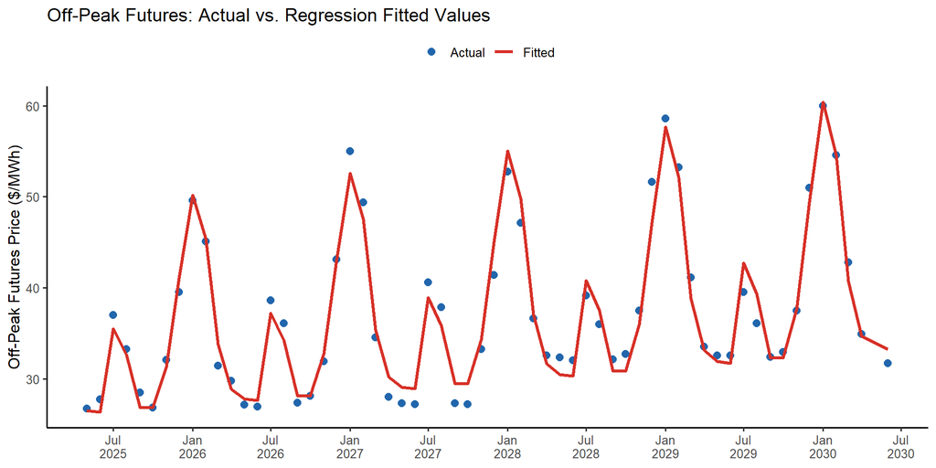

```r
pjm_off[, fitted_log  := fitted(fit_off)]
pjm_off[, fitted_price := exp(fitted_log)]

ggplot(pjm_off, aes(x = date)) +
  geom_point(aes(y = Future, color = "Actual"), size = 2.5) +
  geom_line(aes(y = fitted_price, color = "Fitted"), linewidth = 1.1) +
  scale_x_date(date_breaks = "6 months", date_labels = "%b\n%Y") +
  scale_color_manual(values = c("Actual" = "#2166ac", "Fitted" = "#d73027")) +
  labs(
    title  = "Off-Peak Futures: Actual vs. Regression Fitted Values",
    x      = NULL, y = "Off-Peak Futures Price ($/MWh)", color = NULL
  ) +
  theme_classic(base_size = 12) +
  theme(legend.position = "top")
```

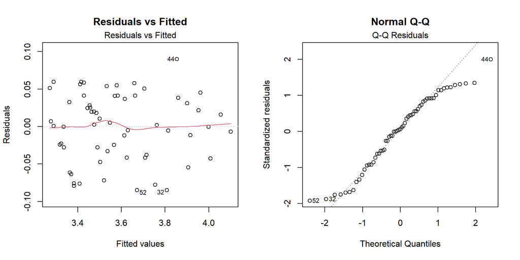

```r
par(mfrow = c(1, 2))
plot(fit_off, which = 1, main = "Residuals vs Fitted")
plot(fit_off, which = 2, main = "Normal Q-Q")
```

```r
par(mfrow = c(1, 1))
```